# Examen_Final_DIP

150074

6/12/2017

# Examen Final Miner??a de Datos Agosto Diciembre 2017

### 142213 David Alcalde

### 150074 Iovannah Rudoy

### 150553 Paloma Lever

## Agenda

- Tema
- Introducción
- Datos
- K-means
- Dendograma
- Preguntas
- Conclusiones

### Tema

A nuestro equipo le fue asignado el siguiente tema (tema 2) en la clase del 4 de Diciembre del 2017:

*Agrupación*

Para este utilizamos una base de datos que contiene información relacionada con los niveles de contaminación de la ciudad de Beijing del 2010 al 2014. Con estos utilizamos k-means con todos los datos numéricos para agrupar en 7 clusters los datos, y después utilizamos los datos del 2014 para crear también 7 clusters.

#### Agrupación

Cuentas con un set de datos que contiene información relacionada a la contaminación de Beijing -**PM2.5**- del 1 de enero de 2010 al 31 de diciembre del 2014. El set cuenta con las siguientes variables

- **No:** número de la observación (no consideramos que esto nos de información relevante)
- **year:** año de la observación
- **month:** mes de la observaciòn
- **day:** día de la observación
- **hour:** hora de la observación
- **pm2.5:** PM2.5 concentration ($ug/m^3$) Este es el nivel de contaminación en la ciudad en ese momento.
- **DEWP:** Dew Point, es una medida de la humedad en el ambiente
- **TEMP:** Temperatura
- **PRES:** Presión ambiental (hPa)
- **cbwd:** Dirección del viento
- **lws:** Velocidad del viento acumulada (m/s)
- **ls:** Horas acumuladas de nieve
- **lr:** Horas acumuladas de lluvia

### Introducción

La contaminación es una de las consecuencias inmediatas de la industrialización y de la tecnificación de la vida y afecta principalmente al medio ambiente y a la salud de las personas. A lo largo de los años, ésta ha dejado una densa capa sobre las ciudades más pobladas convirtiéndola en una amenaza para la salud pública. En muchas ciudades como Beijing y la Ciudad de México se han buscado implementar grandes medidas para intentar mantenerla bajo control y combatir este fenómeno.

El Colegio de Medio Ambiente de la Unversidad de Nanjing relacionó la contaminación con casi un tercio de todas las muertes que se producen en China, poniendo a la polución en el mismo nivel que fumar tabaco. Diversas medidas se han hecho en China para bajar el nivel de polución como lo es establecer políticas de “No Circula”" para autos que no cumplen ciertos criterios, prohibir la producción a empresas que contaminan notablemente por unas horas al día e incluso invertir más en centros de investigación para encontrar una solucion más permamente y eficiente a este problema.

Contando con el set de datos que contiene información relevante respecto al nivel de contaminación de la ciudad de Bejing en 5 años, el objetivo es lograr la agrupación de los datos mediante el uso de dos métodos no supervisados: k-means clustering y dendogramas, para así poder centrar nuestro análisis en estos grupos que comparten diversas características entre sí y reconocer qué es lo que los hace únicos como grupos.

### Datos

```r
#Iovannah
data <- read_csv('~/Desktop/Mineria_de_datos/pollution.csv')

#Paloma
#data <- read_csv("../data/pollution.csv")
summary(data)
```

```
##        No             year          month             day
##  Min.   :    1   Min.   :2010   Min.   : 1.000   Min.   : 1.00
##  1st Qu.:10957   1st Qu.:2011   1st Qu.: 4.000   1st Qu.: 8.00
##  Median :21912   Median :2012   Median : 7.000   Median :16.00
##  Mean   :21912   Mean   :2012   Mean   : 6.524   Mean   :15.73
##  3rd Qu.:32868   3rd Qu.:2013   3rd Qu.:10.000   3rd Qu.:23.00
##  Max.   :43824   Max.   :2014   Max.   :12.000   Max.   :31.00
##
##       hour           pm2.5             DEWP              TEMP
##  Min.   : 0.00   Min.   :  0.00   Min.   :-40.000   Min.   :-19.00
##  1st Qu.: 5.75   1st Qu.: 29.00   1st Qu.:-10.000   1st Qu.:  2.00
##  Median :11.50   Median : 72.00   Median :  2.000   Median : 14.00
##  Mean   :11.50   Mean   : 98.61   Mean   :  1.817   Mean   : 12.45
##  3rd Qu.:17.25   3rd Qu.:137.00   3rd Qu.: 15.000   3rd Qu.: 23.00
##  Max.   :23.00   Max.   :994.00   Max.   : 28.000   Max.   : 42.00
##                  NA's   :2067                       NA's   :2
##       PRES          cbwd                Iws               Is
##  Min.   : 991   Length:43824       Min.   :  0.45   Min.   : 0.00000
##  1st Qu.:1008   Class :character   1st Qu.:  1.79   1st Qu.: 0.00000
##  Median :1016   Mode  :character   Median :  5.37   Median : 0.00000
##  Mean   :1016                      Mean   : 23.89   Mean   : 0.05273
##  3rd Qu.:1025                      3rd Qu.: 21.91   3rd Qu.: 0.00000
##  Max.   :1046                      Max.   :585.60   Max.   :27.00000
##  NA's   :4
##        Ir
##  Min.   : 0.0000
##  1st Qu.: 0.0000
##  Median : 0.0000
##  Mean   : 0.1949
##  3rd Qu.: 0.0000
##  Max.   :36.0000
##
```

```r
rows <- nrow(data)
```

- El set de datos cuenta con el siguiente numero de columnas: 13
- El set de datos cuenta con las siguientes variables: No, year, month, day, hour, pm2.5, DEWP, TEMP, PRES, cbwd, Iws, Is, Ir
- El set de datos cuenta con el siguiente numero de observaciones: 43824

Como podemos observar del primer resumen, pm2.5 es la variable con mas NA’s. De un set que cuenta con 43824 observaciones, 2,067 son NA’s en pm2.5, ese es el 4.7165936% de los datos, que es muy chico, por lo que para nuestro análisis futuro vamos a quitarlo utilizando el comando na.omit().

También podemos ver que la variable número y la variable día no dan realmente información por lo que igual los quitamos antes de hacer un análisis más detallado. Por requerimientos del trabajo, se nos pidió que quitáramos año, mes, día y No. pero para hacer el primer data profiling nos importa utilizar las variables año y mes.

```r
set.seed(142213)

#Eliminamos los NAs para poder hacer el clustering.
data <- na.omit(data)

#Quitamos numero y dia
data<- data[,-c(1,4)]
data$year <- factor(data$year)
data$month <- factor(data$month)
```

|  | uniques | nan | minimo | maximo | promedio | desvest | mediana | moda | primer_cuartil | tercer_cuartil |
| --- | --- | --- | --- | --- | --- | --- | --- | --- | --- | --- |
| hour | 24 | 0 | 0.00 | 23.00 | 11.5014251 | 6.9248968 | 12.00 | 18 | 5.00 | 18.00 |
| pm2.5 | 581 | 0 | 0.00 | 994.00 | 98.6167996 | 92.0525716 | 72.00 | 16 | 29.00 | 137.00 |
| DEWP | 69 | 0 | -40.00 | 28.00 | 1.7513832 | 14.4342402 | 2.00 | 18 | -10.00 | 15.00 |
| TEMP | 62 | 0 | -19.00 | 42.00 | 12.4026730 | 12.1755584 | 14.00 | 24 | 2.00 | 23.00 |
| PRES | 56 | 0 | 991.00 | 1,046.00 | 1,016.4417858 | 10.3008171 | 1,016.00 | 1014 | 1,008.00 | 1,025.00 |
| Iws | 2,721 | 0 | 0.45 | 565.49 | 23.8622105 | 49.6112423 | 5.37 | 0.89 | 1.79 | 21.91 |
| Is | 28 | 0 | 0.00 | 27.00 | 0.0553520 | 0.7789304 | 0.00 | 0 | 0.00 | 0.00 |
| Ir | 37 | 0 | 0.00 | 36.00 | 0.1948935 | 1.4182654 | 0.00 | 0 | 0.00 | 0.00 |

|  | uniques | nan | moda |
| --- | --- | --- | --- |
| year | 5 | 0 | 2013 |
| month | 12 | 0 | 7 |
| cbwd | 4 | 0 | SE |

**Estadística general, Data Profiling*

|  | uniques | uniqueness | minimo | maximo | promedio | desvest | mediana | moda | primer_cuartil | tercer_cuartil |
| --- | --- | --- | --- | --- | --- | --- | --- | --- | --- | --- |
| hour | 24 | 0 | 0.00 | 23.00 | 11.5014251 | 6.9248968 | 12.00 | 18 | 5.00 | 18.00 |
| pm2.5 | 581 | 0 | 0.00 | 994.00 | 98.6167996 | 92.0525716 | 72.00 | 16 | 29.00 | 137.00 |
| DEWP | 69 | 0 | -40.00 | 28.00 | 1.7513832 | 14.4342402 | 2.00 | 18 | -10.00 | 15.00 |
| TEMP | 62 | 0 | -19.00 | 42.00 | 12.4026730 | 12.1755584 | 14.00 | 24 | 2.00 | 23.00 |
| PRES | 56 | 0 | 991.00 | 1,046.00 | 1,016.4417858 | 10.3008171 | 1,016.00 | 1014 | 1,008.00 | 1,025.00 |
| Iws | 2,721 | 0 | 0.45 | 565.49 | 23.8622105 | 49.6112423 | 5.37 | 0.89 | 1.79 | 21.91 |
| Is | 28 | 0 | 0.00 | 27.00 | 0.0553520 | 0.7789304 | 0.00 | 0 | 0.00 | 0.00 |
| Ir | 37 | 0 | 0.00 | 36.00 | 0.1948935 | 1.4182654 | 0.00 | 0 | 0.00 | 0.00 |

Podemos decir del PM2.5 que es una variable numérica que va del 0 al 994, con una desviacion estándar de 92. Esto nos indica uqe hay días muy peligrosos respecto a la contaminación en Beijing, debido a que según las escalas de peligro del pm2.5, a partir de 150 se considera peligroso. Afortunadamente, el 75% de los datos es menor a 137 (esto indica que es peligroso para grupos sensibles, como niños y adultos mayores) pero aún así es importante recalcar esto.

La temperatura en Beijing varía mucho a lo largo del año y en las distintas regiones, va de -19C a 42C, con el 75% de los datos menores a 23C.

DEWP es el grado de humedad, normalmente va de 10 a 26 grados y cualquier valor arriba o abajo puede causar un gran disomfort para el ser humano ya que menor a 10?C incluso menor a 0?C puede ser demasaido seco o mayor a 30?C puede ser asfixiante. En Beijing vemos que va de -40 a 28 lo cual está relacionado con las teperaturas extremas a las que llega a alcanzar.

|  | uniques | uniqueness | moda |
| --- | --- | --- | --- |
| year | 5 | 0 | 2013 |
| month | 12 | 0 | 7 |
| cbwd | 4 | 0 | SE |

Tenemos 5 años, con una moda del 2013, 12 meses con una moda en Julio y 4 valores para cbwd con una moda de SE (South East).

Ahora preparamos los datos para hacer clustering, quitamos las variables categoricas que no nos van a servir para hacer los clusters y luego las pondremos haciendo cbind con el dataset que tiene los clusters para utilizarlas como análisis en el data profiling.

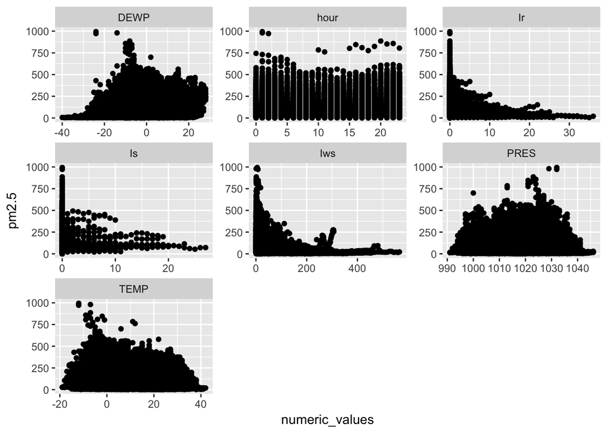

Al ver los datos podemos observar que la hora no es un dato constante.

```
##       hour             pm2.5              DEWP               TEMP
##  Min.   :-1.6609   Min.   :-1.0713   Min.   :-2.89252   Min.   :-2.5792
##  1st Qu.:-0.9388   1st Qu.:-0.7563   1st Qu.:-0.81413   1st Qu.:-0.8544
##  Median : 0.0720   Median :-0.2891   Median : 0.01722   Median : 0.1312
##  Mean   : 0.0000   Mean   : 0.0000   Mean   : 0.00000   Mean   : 0.0000
##  3rd Qu.: 0.9384   3rd Qu.: 0.4170   3rd Qu.: 0.91786   3rd Qu.: 0.8704
##  Max.   : 1.6605   Max.   : 9.7269   Max.   : 1.81850   Max.   : 2.4309
##       PRES               Iws                 Is
##  Min.   :-2.46988   Min.   :-0.47191   Min.   :-0.07106
##  1st Qu.:-0.81953   1st Qu.:-0.44490   1st Qu.:-0.07106
##  Median :-0.04289   Median :-0.37274   Median :-0.07106
##  Mean   : 0.00000   Mean   : 0.00000   Mean   : 0.00000
##  3rd Qu.: 0.83083   3rd Qu.:-0.03935   3rd Qu.:-0.07106
##  Max.   : 2.86950   Max.   :10.91744   Max.   :34.59186
##        Ir
##  Min.   :-0.1374
##  1st Qu.:-0.1374
##  Median :-0.1374
##  Mean   : 0.0000
##  3rd Qu.:-0.1374
##  Max.   :25.2457
```

### K-means

Las variables que más nos interesan para aplicar el algoritmo son las numéricas por lo que quitamos CBWD, año y mes.

+¿Cuántos grupos generaste?

Para decidir el numero de grupos, hacemos el metodo del codo generando hasta 10 clusters.

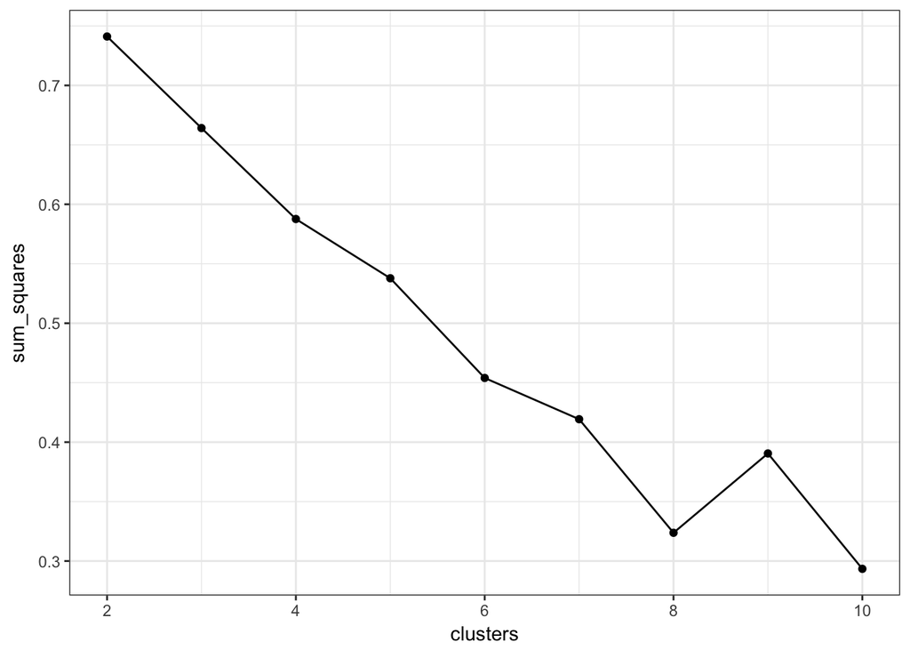

```r
retail_scaled <- data_scale

k_2  <- kmeans(retail_scaled, centers=2, iter.max=10)
k_3  <- kmeans(retail_scaled, centers=3, iter.max=10)
k_4  <- kmeans(retail_scaled, centers=4, iter.max=10)
k_5  <- kmeans(retail_scaled, centers=5, iter.max=10)
k_6  <- kmeans(retail_scaled, centers=6, iter.max=10)
k_7  <- kmeans(retail_scaled, centers=7, iter.max=10)
k_8  <- kmeans(retail_scaled, centers=8, iter.max=10)
k_9  <- kmeans(retail_scaled, centers=9, iter.max=10)
k_10 <- kmeans(retail_scaled, centers=10, iter.max=10)

tot_sumsquares <- k_2$totss

elbow_data <- data.frame(clusters = c(2,3,4,5,6,7,8,9,10),
                         sum_squares =c(k_2$tot.withinss/tot_sumsquares,
                                        k_3$tot.withinss/tot_sumsquares,
                                        k_4$tot.withinss/tot_sumsquares,
                                        k_5$tot.withinss/tot_sumsquares,
                                        k_6$tot.withinss/tot_sumsquares,
                                        k_7$tot.withinss/tot_sumsquares,
                                        k_8$tot.withinss/tot_sumsquares,
                                        k_9$tot.withinss/tot_sumsquares,
                                        k_10$tot.withinss/tot_sumsquares
                                        ))

ggplot(elbow_data, aes(x=clusters, y=sum_squares)) +
  geom_point() +
  geom_line() +
  theme_bw()
```

Con el metodo del codo vemos que el punto óptimo es tener 7 clusters ya que si eligieramos 6 veríamos que aún sigue bajando la suma de cuadrados y con 8 y 9 la diferencia que hay es menor a 0.1.

```r
table(k_7$cluster)
```

```
##
##     1     2     3     4     5     6     7
##  7271  1878   468  8170 10324  9371  4269
```

Podemos observar las coordenadas de cada centroide:

```r
k_7$centers
```

```
##          hour       pm2.5       DEWP       TEMP       PRES         Iws
## 1 -0.88156995 -0.32514137 -0.8985620 -1.1194457  0.9873498 -0.15624415
## 2  0.01140516 -0.77721799 -1.1821117 -0.8408324  0.9174146  3.67108542
## 3 -0.10851066 -0.48786833  0.9119390  0.3242360 -0.5442593 -0.07739598
## 4  0.81409123 -0.41121499 -0.9032124 -0.5366394  0.7122893 -0.02510279
## 5  0.79877162 -0.16087201  0.8257581  1.0858735 -0.9085469 -0.14229802
## 6 -0.92043307 -0.01833246  0.8495861  0.5916585 -0.6998830 -0.26261921
## 7  0.03911783  2.16544933 -0.1828740 -0.6567849  0.3447708 -0.37171392
##             Is          Ir
## 1 -0.011911880 -0.12529528
## 2  1.064407844 -0.13704139
## 3 -0.071061511  7.85657853
## 4 -0.058961938 -0.12274551
## 5 -0.071061511 -0.05853509
## 6 -0.071061511 -0.04524618
## 7  0.000511976 -0.11181636
```

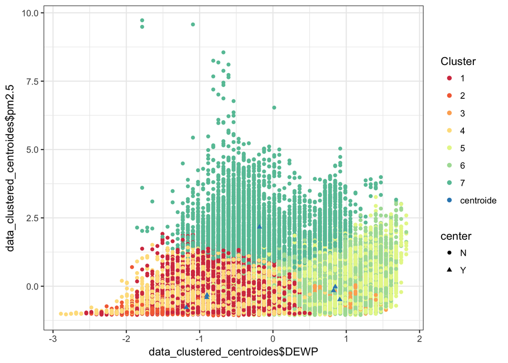

```r
centroides <- as.data.frame(k_7$centers)
centroides$center <- "Y"
centroides$cluster <- "centroide"

data_clustered <- data_scale
data_clustered$cluster <- k_7$cluster
data_clustered$center <- "N"
data_clustered_centroides <- rbind(data_clustered,centroides)



ggplot(data_clustered_centroides, aes(x=data_clustered_centroides$DEWP,
                                      y=data_clustered_centroides$pm2.5,
                                      color= as.factor(cluster), shape=center)) + geom_point() + scale_color_brewer(palette="Spectral",
                                                           name="Cluster") + theme_bw()
```

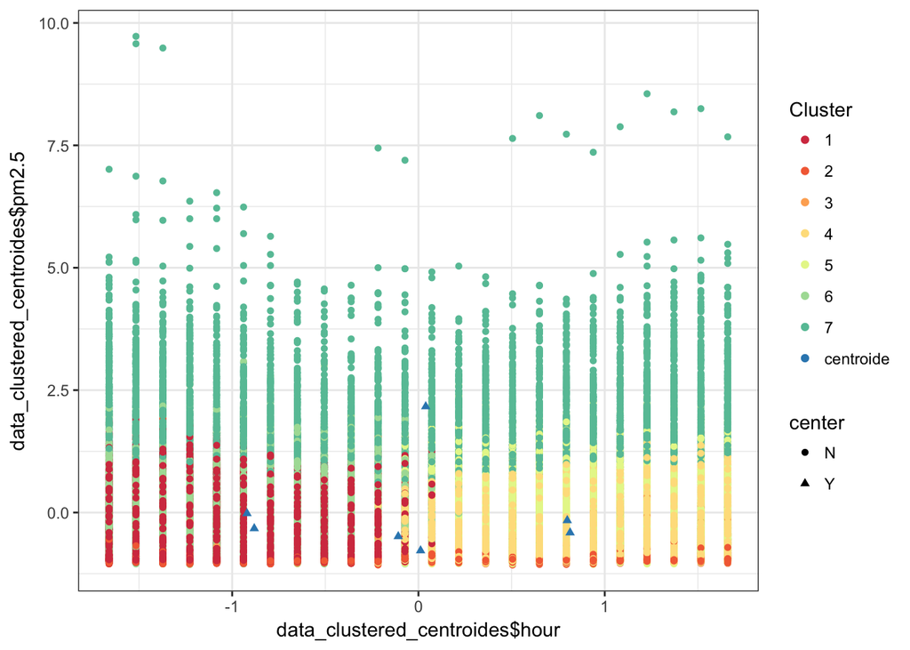

```r
ggplot(data_clustered_centroides, aes(x=data_clustered_centroides$hour,
                                      y=data_clustered_centroides$pm2.5,
                                      color= as.factor(cluster), shape=center)) + geom_point() + scale_color_brewer(palette="Spectral",
                                                           name="Cluster") + theme_bw()
```

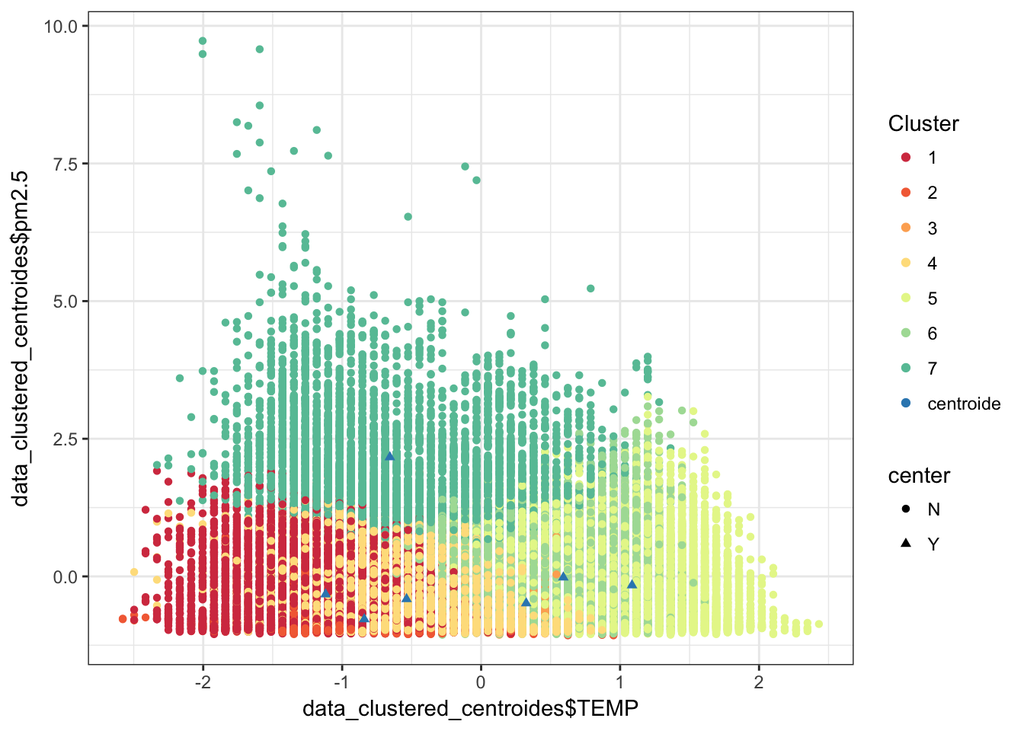

```r
ggplot(data_clustered_centroides, aes(x=data_clustered_centroides$TEMP,
                                      y=data_clustered_centroides$pm2.5,
                                      color= as.factor(cluster), shape=center)) + geom_point() + scale_color_brewer(palette="Spectral",
                                                           name="Cluster") + theme_bw()
```

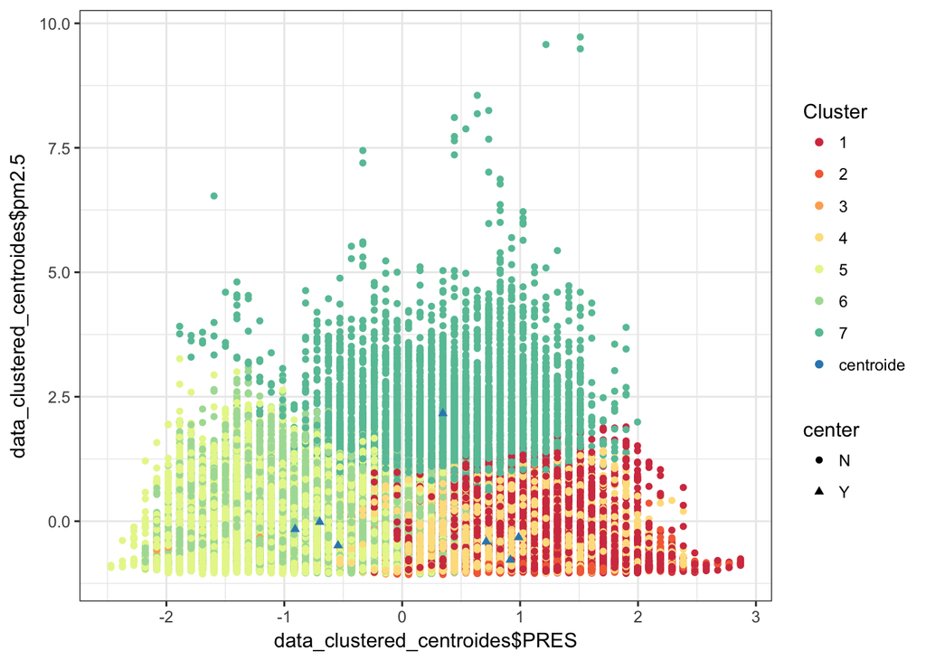

```r
ggplot(data_clustered_centroides, aes(x=data_clustered_centroides$PRES,
                                      y=data_clustered_centroides$pm2.5,
                                      color= as.factor(cluster), shape=center)) + geom_point() + scale_color_brewer(palette="Spectral",
                                                           name="Cluster") + theme_bw()
```

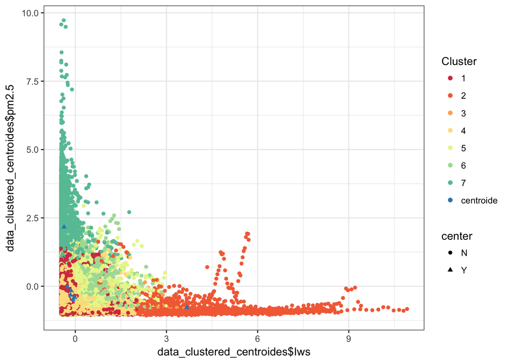

```r
ggplot(data_clustered_centroides, aes(x=data_clustered_centroides$Iws,
                                      y=data_clustered_centroides$pm2.5,
                                      color= as.factor(cluster), shape=center)) + geom_point() + scale_color_brewer(palette="Spectral",
                                                           name="Cluster") + theme_bw()
```

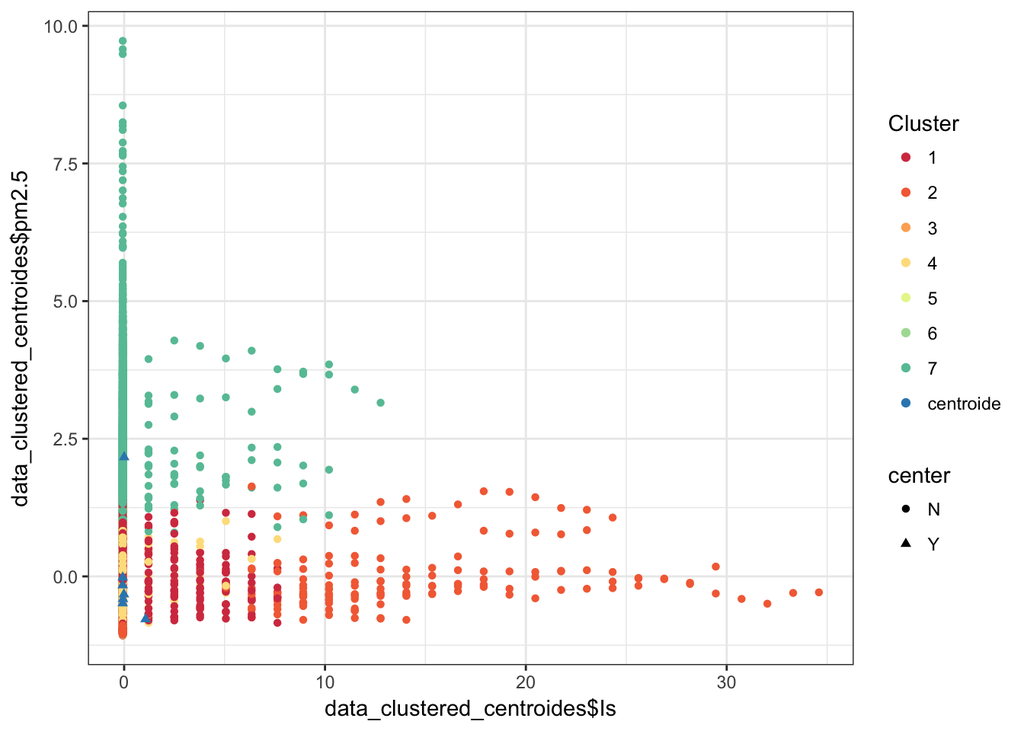

```r
ggplot(data_clustered_centroides, aes(x=data_clustered_centroides$Is,
                                      y=data_clustered_centroides$pm2.5,
                                      color= as.factor(cluster), shape=center)) + geom_point() + scale_color_brewer(palette="Spectral",
                                                           name="Cluster") + theme_bw()
```

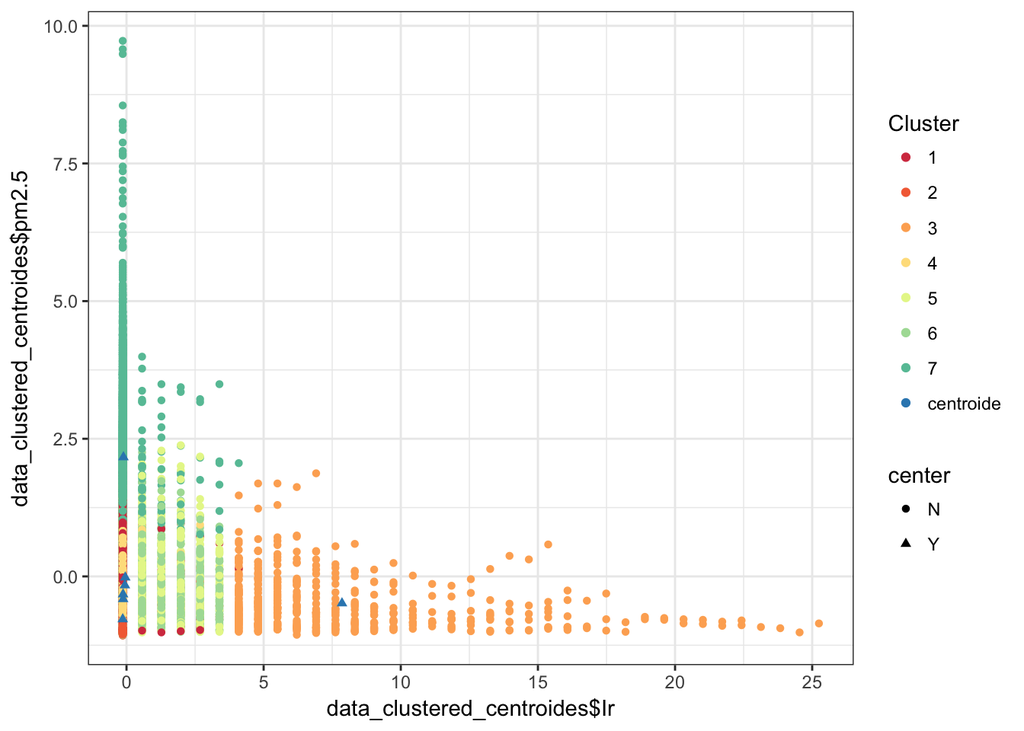

```r
ggplot(data_clustered_centroides, aes(x=data_clustered_centroides$Ir,
                                      y=data_clustered_centroides$pm2.5,
                                      color= as.factor(cluster), shape=center)) + geom_point() + scale_color_brewer(palette="Spectral",
                                                           name="Cluster") + theme_bw()
```

#### Data Profiling

```r
data <- cbind(data_previo,data_clustered$cluster)
```

```r
names(data) <- c("year", "month" ,"hour", "pm2.5", "DEWP", "TEMP", "PRES","cbwd" ,"Iws", "Is", "Ir", "cluster")
data$pm2.5 <- as.numeric(data$pm2.5)
cluster1 <- filter(data,data$cluster == 1)
cluster2 <- filter(data,data$cluster == 2)
cluster3 <- filter(data,data$cluster == 3)
cluster4 <- filter(data,data$cluster == 4)
cluster5 <- filter(data,data$cluster == 5)
cluster6 <- filter(data,data$cluster == 6)
cluster7 <- filter(data,data$cluster == 7)
```

Cluster 1

|  | uniques | nan | minimo | maximo | promedio | desvest | mediana | moda | primer_cuartil | tercer_cuartil |
| --- | --- | --- | --- | --- | --- | --- | --- | --- | --- | --- |
| hour | 15 | 0 | 0.00 | 14.00 | 5.3966442 | 3.4016761 | 5.00 | 6 | 3.00 | 8.00 |
| pm2.5 | 252 | 0 | 2.00 | 275.00 | 68.6867006 | 55.3077029 | 52.00 | 11 | 21.00 | 106.00 |
| DEWP | 45 | 0 | -35.00 | 9.00 | -11.2186769 | 7.7897077 | -11.00 | -10 | -17.00 | -6.00 |
| TEMP | 37 | 0 | -18.00 | 18.00 | -1.2272040 | 6.2438598 | -2.00 | -3 | -6.00 | 3.00 |
| PRES | 40 | 0 | 1,007.00 | 1,046.00 | 1,026.6122954 | 6.2087490 | 1,027.00 | 1028 | 1,022.00 | 1,031.00 |
| Iws | 777 | 0 | 0.45 | 131.42 | 16.1107441 | 24.2229108 | 4.92 | 0.89 | 1.79 | 19.22 |
| Is | 8 | 0 | 0.00 | 7.00 | 0.0460734 | 0.4051874 | 0.00 | 0 | 0.00 | 0.00 |
| Ir | 7 | 0 | 0.00 | 6.00 | 0.0171916 | 0.2434425 | 0.00 | 0 | 0.00 | 0.00 |
| cluster | 1 | 0 | 1.00 | 1.00 | 1.0000000 | 0.0000000 | 1.00 | 1 | 1.00 | 1.00 |

|  | uniques | nan | moda |
| --- | --- | --- | --- |
| year | 5 | 0 | 2010 |
| month | 9 | 0 | 1 |
| cbwd | 4 | 0 | NW |

Cluster 2

|  | uniques | nan | minimo | maximo | promedio | desvest | mediana | moda | primer_cuartil | tercer_cuartil |
| --- | --- | --- | --- | --- | --- | --- | --- | --- | --- | --- |
| hour | 24 | 0 | 0.00 | 23.00 | 11.5804047 | 6.7720066 | 12.00 | 14 | 6.00 | 17.0000 |
| pm2.5 | 153 | 0 | 0.00 | 276.00 | 27.0718850 | 34.8168149 | 15.00 | 13 | 11.00 | 25.0000 |
| DEWP | 47 | 0 | -34.00 | 13.00 | -15.3115016 | 8.4167797 | -18.00 | -20 | -22.00 | -8.0000 |
| TEMP | 47 | 0 | -19.00 | 29.00 | 2.1650692 | 8.9190651 | 0.00 | 0 | -4.00 | 7.0000 |
| PRES | 44 | 0 | 1,001.00 | 1,046.00 | 1,025.8919063 | 8.3918757 | 1,027.00 | 1032 | 1,019.00 | 1,032.0000 |
| Iws | 1,426 | 0 | 0.45 | 565.49 | 205.9893184 | 91.5980335 | 188.86 | 0.89 | 147.52 | 257.9375 |
| Is | 25 | 0 | 0.00 | 27.00 | 0.8844515 | 3.3669178 | 0.00 | 0 | 0.00 | 0.0000 |
| Ir | 2 | 0 | 0.00 | 1.00 | 0.0005325 | 0.0230756 | 0.00 | 0 | 0.00 | 0.0000 |
| cluster | 1 | 0 | 2.00 | 2.00 | 2.0000000 | 0.0000000 | 2.00 | 2 | 2.00 | 2.0000 |

|  | uniques | nan | moda |
| --- | --- | --- | --- |
| year | 5 | 0 | 2010 |
| month | 11 | 0 | 12 |
| cbwd | 4 | 0 | NW |

Cluster 3

|  | uniques | nan | minimo | maximo | promedio | desvest | mediana | moda | primer_cuartil | tercer_cuartil |
| --- | --- | --- | --- | --- | --- | --- | --- | --- | --- | --- |
| hour | 24 | 0 | 0.00 | 23.00 | 10.75000 | 6.624487 | 10.00 | 3 | 5.00 | 16.00 |
| pm2.5 | 139 | 0 | 1.00 | 271.00 | 53.70726 | 45.400358 | 40.00 | 12 | 20.00 | 74.25 |
| DEWP | 25 | 0 | 0.00 | 24.00 | 14.91453 | 6.294789 | 16.00 | 20 | 10.00 | 20.00 |
| TEMP | 25 | 0 | 2.00 | 26.00 | 16.35043 | 6.070699 | 18.00 | 21 | 13.00 | 21.00 |
| PRES | 33 | 0 | 995.00 | 1,029.00 | 1,010.83547 | 6.919285 | 1,011.00 | 1011 | 1,006.00 | 1,015.00 |
| Iws | 158 | 0 | 0.45 | 208.79 | 20.02250 | 33.497378 | 6.93 | 1.79 | 1.79 | 22.47 |
| Is | 1 | 0 | 0.00 | 0.00 | 0.00000 | 0.000000 | 0.00 | 0 | 0.00 | 0.00 |
| Ir | 31 | 0 | 6.00 | 36.00 | 11.33761 | 6.016512 | 9.00 | 6 | 7.00 | 13.25 |
| cluster | 1 | 0 | 3.00 | 3.00 | 3.00000 | 0.000000 | 3.00 | 3 | 3.00 | 3.00 |

|  | uniques | nan | moda |
| --- | --- | --- | --- |
| year | 5 | 0 | 2012 |
| month | 9 | 0 | 7 |
| cbwd | 4 | 0 | NW |

Cluster 4

|  | uniques | nan | minimo | maximo | promedio | desvest | mediana | moda | primer_cuartil | tercer_cuartil |
| --- | --- | --- | --- | --- | --- | --- | --- | --- | --- | --- |
| hour | 17 | 0 | 7.00 | 23.00 | 17.1389229 | 3.7773335 | 17.00 | 23 | 14.00 | 20.00 |
| pm2.5 | 221 | 0 | 2.00 | 238.00 | 60.7634027 | 48.5482871 | 47.00 | 16 | 20.00 | 90.00 |
| DEWP | 53 | 0 | -40.00 | 12.00 | -11.2858017 | 8.3166732 | -12.00 | -12 | -18.00 | -5.00 |
| TEMP | 44 | 0 | -18.00 | 26.00 | 5.8687882 | 7.5553480 | 6.00 | 2 | 0.00 | 11.00 |
| PRES | 38 | 0 | 1,005.00 | 1,042.00 | 1,023.7789474 | 6.1855543 | 1,024.00 | 1025 | 1,019.00 | 1,028.00 |
| Iws | 990 | 0 | 0.45 | 138.57 | 22.6168299 | 29.4978563 | 8.05 | 0.89 | 2.67 | 31.73 |
| Is | 7 | 0 | 0.00 | 6.00 | 0.0094247 | 0.1729237 | 0.00 | 0 | 0.00 | 0.00 |
| Ir | 7 | 0 | 0.00 | 6.00 | 0.0208078 | 0.2576917 | 0.00 | 0 | 0.00 | 0.00 |
| cluster | 1 | 0 | 4.00 | 4.00 | 4.0000000 | 0.0000000 | 4.00 | 4 | 4.00 | 4.00 |

|  | uniques | nan | moda |
| --- | --- | --- | --- |
| year | 5 | 0 | 2013 |
| month | 9 | 0 | 3 |
| cbwd | 4 | 0 | NW |

Cluster 5

|  | uniques | nan | minimo | maximo | promedio | desvest | mediana | moda | primer_cuartil | tercer_cuartil |
| --- | --- | --- | --- | --- | --- | --- | --- | --- | --- | --- |
| hour | 15 | 0 | 9.00 | 23.00 | 17.0328361 | 3.706409 | 17.0 | 16 | 14.00 | 20.00 |
| pm2.5 | 307 | 0 | 1.00 | 399.00 | 83.8081170 | 59.117250 | 72.0 | 16 | 36.00 | 120.00 |
| DEWP | 47 | 0 | -18.00 | 28.00 | 13.6705734 | 7.895205 | 15.0 | 17 | 9.00 | 20.00 |
| TEMP | 38 | 0 | 4.00 | 42.00 | 25.6237892 | 5.217583 | 26.0 | 28 | 22.00 | 29.00 |
| PRES | 34 | 0 | 991.00 | 1,024.00 | 1,007.0830105 | 5.662399 | 1,007.0 | 1006 | 1,003.00 | 1,011.00 |
| Iws | 808 | 0 | 0.45 | 178.78 | 16.8026288 | 21.786980 | 8.5 | 1.79 | 3.13 | 22.81 |
| Is | 1 | 0 | 0.00 | 0.00 | 0.0000000 | 0.000000 | 0.0 | 0 | 0.00 | 0.00 |
| Ir | 6 | 0 | 0.00 | 5.00 | 0.1118752 | 0.545497 | 0.0 | 0 | 0.00 | 0.00 |
| cluster | 1 | 0 | 5.00 | 5.00 | 5.0000000 | 0.000000 | 5.0 | 5 | 5.00 | 5.00 |

|  | uniques | nan | moda |
| --- | --- | --- | --- |
| year | 5 | 0 | 2014 |
| month | 9 | 0 | 7 |
| cbwd | 4 | 0 | SE |

Cluster 6

|  | uniques | nan | minimo | maximo | promedio | desvest | mediana | moda | primer_cuartil | tercer_cuartil |
| --- | --- | --- | --- | --- | --- | --- | --- | --- | --- | --- |
| hour | 14 | 0 | 0.00 | 13.00 | 5.1275211 | 3.3179215 | 5.00 | 0 | 2.00 | 8.00 |
| pm2.5 | 324 | 0 | 1.00 | 383.00 | 96.9292498 | 62.2575160 | 86.00 | 80 | 50.00 | 136.00 |
| DEWP | 44 | 0 | -16.00 | 28.00 | 14.0145129 | 7.1207607 | 16.00 | 18 | 9.00 | 19.00 |
| TEMP | 32 | 0 | 1.00 | 32.00 | 19.6064454 | 5.2975556 | 20.00 | 23 | 16.00 | 24.00 |
| PRES | 34 | 0 | 994.00 | 1,027.00 | 1,009.2324192 | 6.0904056 | 1,009.00 | 1006 | 1,005.00 | 1,014.00 |
| Iws | 740 | 0 | 0.45 | 170.78 | 10.8333454 | 19.4133291 | 3.13 | 0.89 | 1.78 | 9.83 |
| Is | 1 | 0 | 0.00 | 0.00 | 0.0000000 | 0.0000000 | 0.00 | 0 | 0.00 | 0.00 |
| Ir | 6 | 0 | 0.00 | 5.00 | 0.1307224 | 0.6271061 | 0.00 | 0 | 0.00 | 0.00 |
| cluster | 1 | 0 | 6.00 | 6.00 | 6.0000000 | 0.0000000 | 6.00 | 6 | 6.00 | 6.00 |

|  | uniques | nan | moda |
| --- | --- | --- | --- |
| year | 5 | 0 | 2014 |
| month | 10 | 0 | 5 |
| cbwd | 4 | 0 | SE |

Cluster 7

|  | uniques | nan | minimo | maximo | promedio | desvest | mediana | moda | primer_cuartil | tercer_cuartil |
| --- | --- | --- | --- | --- | --- | --- | --- | --- | --- | --- |
| hour | 24 | 0 | 0.00 | 23.00 | 11.7723120 | 7.2130954 | 12.00 | 23 | 5.00 | 18.00 |
| pm2.5 | 430 | 0 | 148.00 | 994.00 | 297.9519794 | 91.7855513 | 278.00 | 227 | 232.00 | 344.00 |
| DEWP | 49 | 0 | -25.00 | 26.00 | -0.8882642 | 8.0552174 | -3.00 | -5 | -7.00 | 4.00 |
| TEMP | 46 | 0 | -16.00 | 29.00 | 4.4059499 | 7.8254668 | 3.00 | -3 | -2.00 | 11.00 |
| PRES | 41 | 0 | 997.00 | 1,037.00 | 1,019.9932068 | 6.5760778 | 1,020.00 | 1021 | 1,016.00 | 1,025.00 |
| Iws | 268 | 0 | 0.45 | 111.78 | 5.4210213 | 9.3540473 | 1.79 | 0.89 | 0.89 | 5.37 |
| Is | 11 | 0 | 0.00 | 10.00 | 0.0557508 | 0.5400396 | 0.00 | 0 | 0.00 | 0.00 |
| Ir | 7 | 0 | 0.00 | 6.00 | 0.0363083 | 0.3323302 | 0.00 | 0 | 0.00 | 0.00 |
| cluster | 1 | 0 | 7.00 | 7.00 | 7.0000000 | 0.0000000 | 7.00 | 7 | 7.00 | 7.00 |

|  | uniques | nan | moda |
| --- | --- | --- | --- |
| year | 5 | 0 | 2013 |
| month | 11 | 0 | 10 |
| cbwd | 4 | 0 | cv |